# Chap5_3

J.H AHN

2021 12 7

## 5.3 Fitted values and residuals

### Fitted values

시계열에서 각 관측값은 이전의 모든 관측치를 이용하여 예측할 수 있고, 이렇게 예측된 값을 적합값(fitted values)라 함.  
관측값(observations) $y_{1},\dots,y_{t-1}$을 이용하여 예측한 $y_t$라는 의미로 $\hat{y}_{t|t-1}$와 같이 쓴다.  
사실, 미래 관측값을 포함하여 사용할 수 있는 모든 관측값으로 예측 기법에 들어가는 매개변수를 추정했기 때문에 적합값(fitted value)은 종종 진짜 예측(true forecasts)이 아니다.  
예를 들어 만약 우리가 평균 기법을 사용한다고 하면, 적합값은 $\hat{y}_t = \hat{c}$으로 주어진다.  
여기서 $\hat c$는 $t$시간이 지난 후 것들을 포함하여 가능한 모든 관측치의 계산값의 평균을 의미한다.

drift method를 사용했다면, drift parameter는 모든 사용 가능한 관측값을 사용한 것으로 추정(estimate)한 것으로 보고 적합값을 $\hat{y}_t = y_{t-1} + \hat{c}$와 같이 나타낼 수 있다.  
이 경우 $\hat{c} = (y_T-y_1)/(T-1)$이다.

$c$값을 예측할 때 시간$t$이후의 관측값이 포함되어 있다면 적합값은 진짜 예측값이라 볼 수 없지만, naive 혹은 seasonal naive와 같이 시간$t$이후의 관측값이 포함되어 있지 않다면 적합값은 진짜 예측값이라 할 수 있다.

### residuals

시계열 모델에서 “잔차(Residuals)”는 모델을 맞춘 후에 남는 것을 의미한다.  
다양한 (하지만 전부는 아닌) 시계열 모델에서, 잔차(residual)는 관측값과 대응되는 적합값(fitted value)과 관측값의 차이이다.

$$e_{t} = y_{t}-\hat{y}_{t}$$

만약 변환한 모델에서 변환된 스케일로 발생한 잔차는 **“innovation residuals”**이라 하고 이 잔차들은 모델을 평가하는데 유용하게 사용된다.

예를 들어 모델을 로그 변환하여, $w_t = \log(y_t)$로 만들었다면 innovation residuals은 $w_t - \hat{w}_t$로 나타낼 수 있고, regular residuals은 $y_t - \hat{y}_t$로 나타낼 수 있다.

어떤 모델에서 적합값과 잔차를 얻기 위해서는 `augment()`함수를 사용한다.

```r
# Set training data from 1992 to 2006
train <- aus_production %>%
    filter_index("1992 Q1" ~ "2006 Q4")
# Fit the models
beer_fit <- train %>%
    model(
        Mean = MEAN(Beer),
        `Naïve` = NAIVE(Beer),
        `Seasonal naïve` = SNAIVE(Beer)
    )
```

```r
augment(beer_fit)
```

```
## # A tsibble: 180 x 6 [1Q]
## # Key:       .model [3]
##    .model Quarter  Beer .fitted .resid .innov
##    <chr>    <qtr> <dbl>   <dbl>  <dbl>  <dbl>
##  1 Mean   1992 Q1   443    436.   6.55   6.55
##  2 Mean   1992 Q2   410    436. -26.4  -26.4
##  3 Mean   1992 Q3   420    436. -16.4  -16.4
##  4 Mean   1992 Q4   532    436.  95.6   95.6
##  5 Mean   1993 Q1   433    436.  -3.45  -3.45
##  6 Mean   1993 Q2   421    436. -15.4  -15.4
##  7 Mean   1993 Q3   410    436. -26.4  -26.4
##  8 Mean   1993 Q4   512    436.  75.6   75.6
##  9 Mean   1994 Q1   449    436.  12.6   12.6
## 10 Mean   1994 Q2   381    436. -55.4  -55.4
## # ... with 170 more rows
```

결과에서

- `.fitted`는 적합값을 의미
- `.resid`는 잔차를 의미
- `.innov`는 innovation residuals를 의미하는데 이 경우는 (변환이 없어)잔차와 동일한다.

잔차(residuals)는 모델이 적절하게 정보를 담아냈는지 확인하는데 유용하다.  
이런 목적으로 innovation residuals을 사용하는데 만약 innovation residuals이 어떤 패턴을 가진다면 모델은 더 개선할 여지가 있다는 의미이다. (중요! 잔차는 어떠한 상관관계나 추세를 가져서는 안된다.)

## 5.4 Residual diagnostics

좋은 예측 기법은 다음과 같은 특징을 갖는 잔차(residual)가 발생한다.

1. 잔차(residual)에 상관 관계가 없다.  
   잔차 사이에 상관관계(correlation)가 있다면, 잔차에 예측값을 계산할 때 사용해야하는 정보가 남아 있다는 의미다.
2. 잔차의 평균이 0이다.  
   잔차의 평균이 0이 아니라면, 예측값이 편향(bias)될 수 있다.

이러한 특징을 만족하지 않는 예측 기법은 개선할 필요가 있다.  
이러한 특징 중에서 하나를 만족하지 않는다면, 더 나은 예측치를 내는 기법으로 수정될 수 있다.  
예를 들어 편향(bias)을 보정해야 한다면, 잔차의 평균이 $m$이면, 단순히 모든 예측치에 $m$을 더하여 편향 문제를 해결할 수 있다.  
상관(correlation) 문제를 고치는 것은 어렵기 때문에 이후에 별도로 다룬다.

이러한 핵심적인 특징에 더하여, (필수적인 것은 아니지만) 다음과 같은 잔차의 두 가지 성질도 유용합니다.

3. 잔차의 분산이 상수이다.
4. 잔차가 정규 분포를 따른다.

이러한 두 가지 성질은 예측구간(prediction interval)을 계산하기 쉽도록 만든다.  
하지만, 이러한 특징을 만족하지 않는 어떤 예측 기법이 무조건 나쁘다는 것이 아니고 때때로 박스-칵스(Box-Cox) 변환을 적용하면 이러한 특징이 만족되는 경우도 있다.

Box-Cox변환으로도 위 특성을 만족시키지 못한다면 잔차(residual)의 분산이 상수이면서 정규 분포(normal distribution)를 가질 수 있도록 할 수 있는 일이 보통은 거의 없습니다.  
대신에 예측 구간(prediction interval)을 얻기 위해 다른 방식이 필요합니다.

### Example: Forecasting Google daily closing stock prices

구글의 주가를 예시로 살펴보자.  
구글 주가는 2015년 7월 17일날 16%가 상승하여 아래와 같은 추세를 나타내었다.

```r
# Re-index based on trading days
google_stock <-
    gafa_stock %>%
    filter(Symbol == "GOOG", year(Date) >= 2015) %>%
    mutate(day = row_number()) %>%
    update_tsibble(index = day, regular = TRUE)

# Filter the year of interest
google_2015 <-
    google_stock %>%
    filter(year(Date) == 2015)

google_2015
```

```
## # A tsibble: 252 x 9 [1]
## # Key:       Symbol [1]
##    Symbol Date        Open  High   Low Close Adj_Close  Volume   day
##    <chr>  <date>     <dbl> <dbl> <dbl> <dbl>     <dbl>   <dbl> <int>
##  1 GOOG   2015-01-02  526.  528.  521.  522.      522. 1447600     1
##  2 GOOG   2015-01-05  520.  521.  510.  511.      511. 2059800     2
##  3 GOOG   2015-01-06  512.  513.  498.  499.      499. 2899900     3
##  4 GOOG   2015-01-07  504.  504.  497.  498.      498. 2065100     4
##  5 GOOG   2015-01-08  495.  501.  488.  500.      500. 3353600     5
##  6 GOOG   2015-01-09  502.  502.  492.  493.      493. 2069400     6
##  7 GOOG   2015-01-12  492.  493.  485.  490.      490. 2322400     7
##  8 GOOG   2015-01-13  496.  500.  490.  493.      493. 2370500     8
##  9 GOOG   2015-01-14  492.  500.  490.  498.      498. 2235700     9
## 10 GOOG   2015-01-15  503.  503.  495.  499.      499. 2715800    10
## # ... with 242 more rows
```

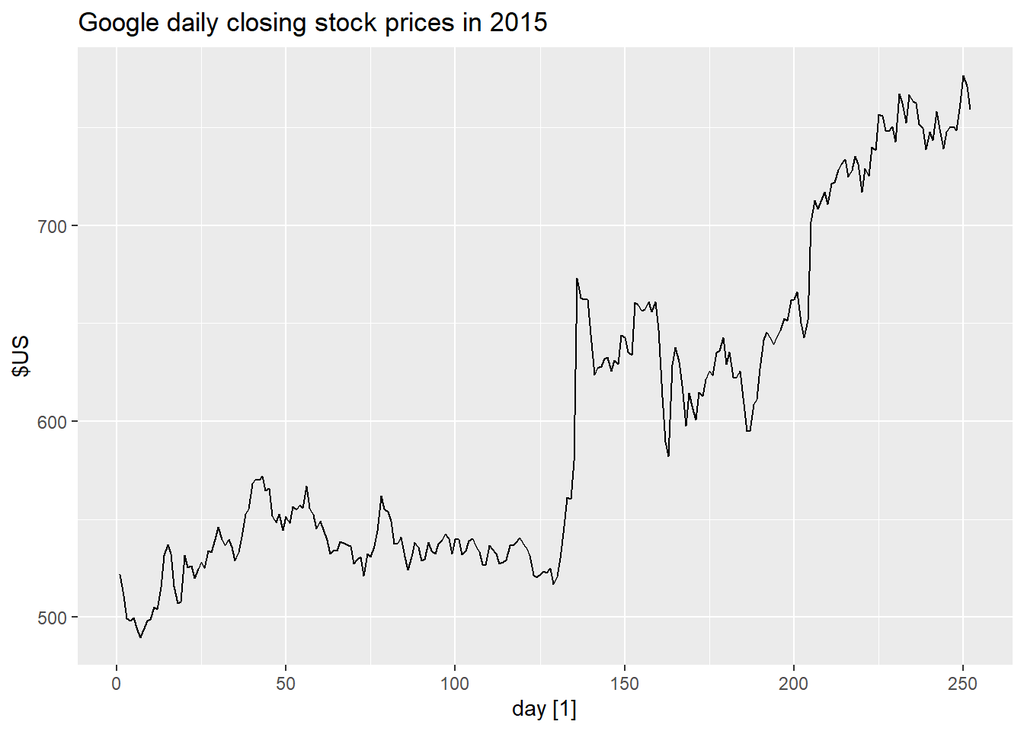

```r
autoplot(google_2015, Close) +
    labs(y = "$US",
         title = "Google daily closing stock prices in 2015")
```

naive method를 사용하여 이 시계열 데이터를 예측할 경우 발생하는 잔차는 아래와 같다.  
7월에 주가가 크게 뛰었을 때 큰 잔차가 발생함을 확인할 수 있다.

```r
aug <-
    google_2015 %>%
    model(NAIVE(Close)) %>%
    augment()

aug
```

```
## # A tsibble: 252 x 7 [1]
## # Key:       Symbol, .model [1]
##    Symbol .model         day Close .fitted  .resid  .innov
##    <chr>  <chr>        <int> <dbl>   <dbl>   <dbl>   <dbl>
##  1 GOOG   NAIVE(Close)     1  522.     NA   NA      NA
##  2 GOOG   NAIVE(Close)     2  511.    522. -10.9   -10.9
##  3 GOOG   NAIVE(Close)     3  499.    511. -11.8   -11.8
##  4 GOOG   NAIVE(Close)     4  498.    499.  -0.855  -0.855
##  5 GOOG   NAIVE(Close)     5  500.    498.   1.57    1.57
##  6 GOOG   NAIVE(Close)     6  493.    500.  -6.47   -6.47
##  7 GOOG   NAIVE(Close)     7  490.    493.  -3.60   -3.60
##  8 GOOG   NAIVE(Close)     8  493.    490.   3.61    3.61
##  9 GOOG   NAIVE(Close)     9  498.    493.   4.66    4.66
## 10 GOOG   NAIVE(Close)    10  499.    498.   0.915   0.915
## # ... with 242 more rows
```

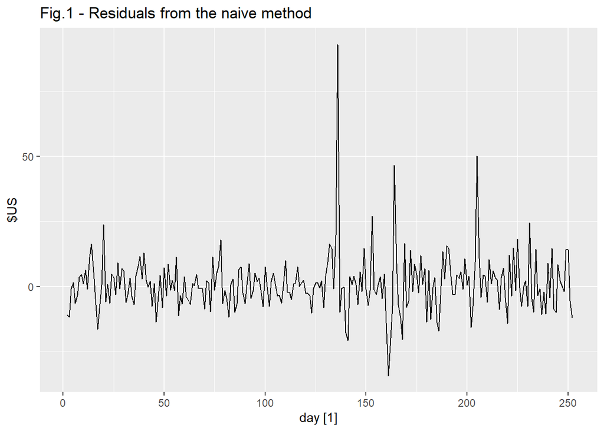

```r
aug %>% autoplot(.innov) +
    labs(y = "$US",
         title = "Fig.1 - Residuals from the naive method")
```

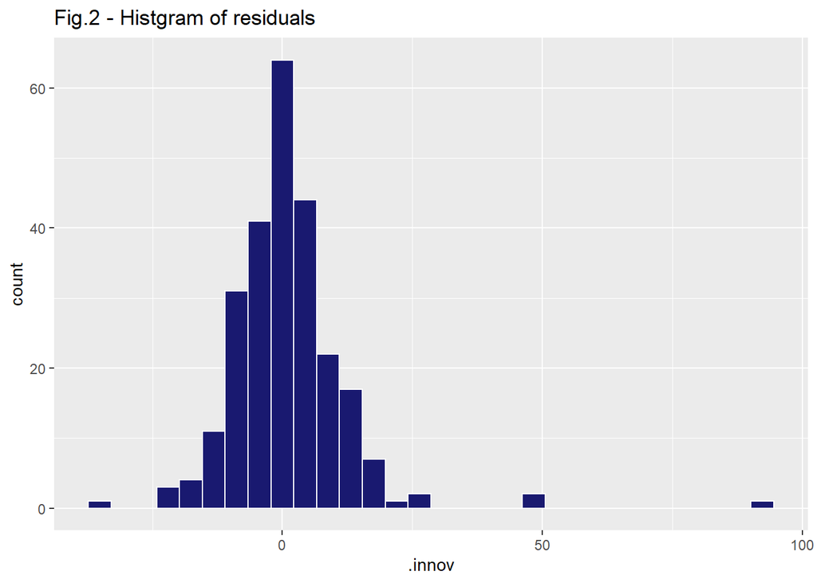

```r
aug %>% ggplot(aes(.innov)) +
    geom_histogram(color = "#FFFFFF", fill = "#191970") +
    labs(title = "Fig.2 - Histgram of residuals")
```

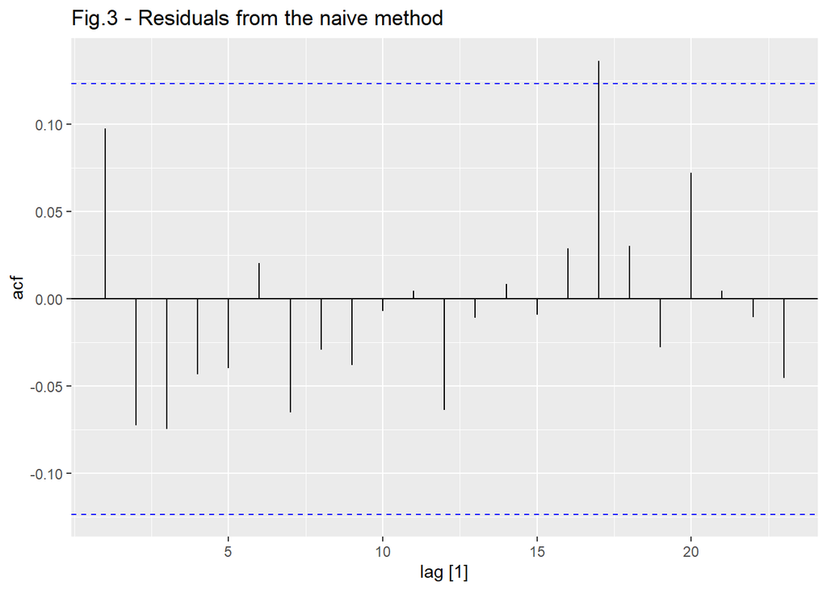

```r
aug %>%
    ACF(.innov) %>%
    autoplot() +
    labs(title = "Fig.3 - Residuals from the naive method")
```

위 그래프로 사용 가능한 정보가 모두 포함되어 있는 (= 잘 만들어진) 모델로 예측되고 있음을 알 수 있다.  
잔차의 평균은 0에 가깝고(Fig.1, Fig.2), 잔차 계열에는 유의미한 상관관계가 없다.(Fig.3) 잔차의 자기상관에는 하나의 이상치를 제외하고는 과거 데이터에서 잔차 변동이 거의 동일하게 유지되고 분산이 일정하다는 것을 알 수 있다. (Fig.3)  
이는 Fig.2 히스토그램에서도 확인할 수 있다. 히스토그램의 오른쪽에 이상치가 일부 존재하지만 이 예측모델은 나쁘지 않겠지만 이부 예측 구간은 부정확 할 수도 있다고 예상할 수 있다.

이러한 잔차 진단 그래프를 한 번에 편리하게 만들기 위해 `feasts::gg_tsresiduals()`함수를 사용할 수 있다.

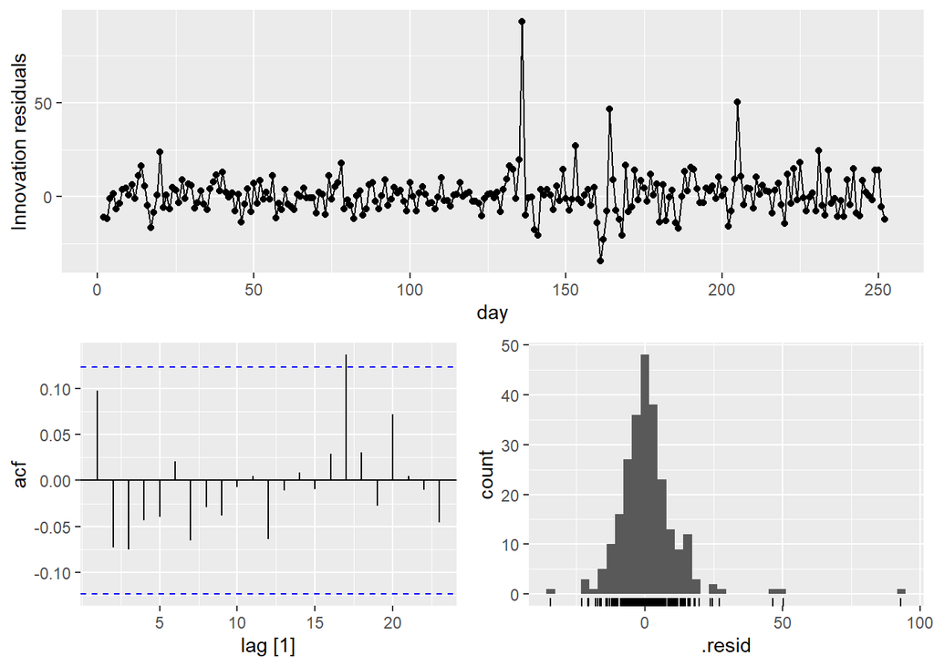

```r
google_2015 %>%
    model(NAIVE(Close)) %>%
    gg_tsresiduals()
```

### Portmanteau tests for autocorrelation

ACF Plot을 보는 것 외에 각각의 잔차를 확인하는 대신 전체 $r_f$값을 묶어서 자기상관을 확인할 수 있다.

$r_k$는 시차 $k$에 대한 자기상관을 의미한다. 잔차가 튀는 수준이 허용 가능한 범위 내에 있는지 확인하기 위해 ACF Plot을 확인하지만 명시적이고 정량적인 값이 없기 때문에 놓칠 가능성도 있다.  
이런 테스트를 충분하게 많이 하면 적어도 하나의 테스트에서는 False positive를 결론으로 낼 수 있기 때문에 테스트에서 잔차에 자기 상관이 없다고 나오더라도 실제는 자기상관성을 가지고 있을 수도 있다.

이러한 문제를 극복하기 위해서 첫번째 $\ell$자기상관이 White noise와 다른지 테스트해야 한다.  
자기상관에 대한 테스트를 포르망토 테스트(portmanteau test)라고 하며, 이는 여러 의류 항목을 나르는 여행가방이나 옷걸이를 설명하는 프랑스어 단어에서 유래하였다.

이런 테스트 중 하나로 아래 수식으로 표현되는 Box-Pierce test가 있다.

$$Q = T \sum_{k=1}^\ell r_k^2$$

where, $\ell$: 관측치 $T$를 고려한 최대 lag

만약 각각의 $r_k$가 0에 가까이 가게되면, $Q$는 작아진다. 반대로 만약 각각의 $r_k$이 커지게 되면(음수든 양수든) $Q$는 커진다.  
계절추세이 없는 데이터는 $\ell = 10$을 사용하고, 계절추세가 있는 데이터는 $\ell = 2m$ (여기서 $m$은 계절추세의 기간)를 사용하는 것이 일반적이다.  
그러나 $\ell$이 클 경우에는 테스트 결과가 좋지 않으므로 이 값들이 $T/5$보다 클 경우에는 $\ell = T/5$를 사용한다.  
이와 관련된 (좀 더 정확한) 시험으로는 **Ljung-Box test가 있다.

$$Q^* = T(T+2) \sum_{k=1}^\ell (T-k)^{-1}r_k^2$$

큰 값의 $Q^*$는 자기상관성이 White noise에서 온 것이 아님을 의미한다.  
얼마나 커야 큰 값이라 볼 수 있을까?  
만약 자기상관성이 White noise에서 오지 않았다면 $Q$와 $Q^*$는 $(\ell - K)$자유도에서 $\chi^2$분포를 나타낼 것이다. (여기서 $K$는 모델의 Parameter 수를 의미한다. 모델으로 부터 나온 잔차가 아닌 Raw data로 계산하여 나온 잔차라면 $K$값은 0으로 보면 된다.)

구글 주가 예제로 돌아와서 naive method는 parameter가 없으므로 $K=0$으로 볼 수 있다.  
코드에서 $\ell=$`lag`, $K=$`dof`로 표현된다.

```r
aug %>%
    features(.innov, box_pierce, lag = 10, dof = 0)
```

```
## # A tibble: 1 x 4
##   Symbol .model       bp_stat bp_pvalue
##   <chr>  <chr>          <dbl>     <dbl>
## 1 GOOG   NAIVE(Close)    7.74     0.654
```

```r
aug %>%
    features(.innov, ljung_box, lag = 10, dof = 0)
```

```
## # A tibble: 1 x 4
##   Symbol .model       lb_stat lb_pvalue
##   <chr>  <chr>          <dbl>     <dbl>
## 1 GOOG   NAIVE(Close)    7.91     0.637
```

테스트 결과 $Q$와 $Q^*$모두 특별한 점을 확인할 수 없다. (p-value가 상대적으로 크다.)  
Ljung-box test는 결과로 산출되는 $Q^*$값이 중요한데, 결과에서 보는 바와 같이 p-value가 0.05보다 크기 때문에 통계적으로 유의미하지 않다고 본다. 따라서 유의미하지 않다면 (0.05보다 크다면) 해당 시계열의 잔차의 자기상관성은 White noise와 다르지 않다(= white noise이다.)고 판단할 수 있다.

또 다른 주가 예측을 위한 기법으로는 drift method가 있다.

```r
fit <-
    google_2015 %>%
    model(RW(Close ~ drift()))

tidy(fit)
```

```
## # A tibble: 1 x 7
##   Symbol .model              term  estimate std.error statistic p.value
##   <chr>  <chr>               <chr>    <dbl>     <dbl>     <dbl>   <dbl>
## 1 GOOG   RW(Close ~ drift()) b        0.944     0.705      1.34   0.182
```

`tidy()`함수로 예측 파라미터(estimated parameter)인 drift coefficient(b, 관측치에서 측정된 일평균 변화량)이 있음을 확인할 수 있다.  
따라서 Ljung-Box test를 할 때는 estimated parameter를 반영하여 $K=1$로 설정해야 한다.

```r
augment(fit) %>%
    features(.innov, ljung_box, lag = 10, dof = 1)
```

```
## # A tibble: 1 x 4
##   Symbol .model              lb_stat lb_pvalue
##   <chr>  <chr>                 <dbl>     <dbl>
## 1 GOOG   RW(Close ~ drift())    7.91     0.543
```

random walk method를 사용한 모델의 $Q^*$값도 충분히 큰 p-value가 확인되었으므로 잔차가 white noise와 다르지 않다고 볼 수 있다.